# Netflix Content Analysis

Insights for a Competing Streaming Service

Student 26572982

June 18, 2026

# 1 Executive Summary

This report analyses Netflix content data (up to 2022) covering 5,765 titles across movies and shows, supplemented with IMDb ratings, production countries, genres and movie descriptions. The analysis is compared against HBO to identify what works and what does not work in streaming content, to inform the launch of a competing streaming service.

**Key findings:**

- The US dominates Netflix content volume but does not produce the highest rated movies
- Japan leads in average IMDb ratings — smaller content libraries tend to be more curated and higher quality
- Non-Western countries produce significantly longer movies than the 90-minute Western standard
- Drama and comedy dominate Netflix’s genre strategy — driven by universal cross-cultural appeal
- Netflix’s movie descriptions centre on love, family and relationships — emotional storytelling is the dominant theme
- HBO maintains a higher average IMDb score (6.77) vs Netflix (6.26) — quality vs quantity tradeoff is clear
- A market gap exists for a platform combining HBO’s quality curation with Netflix’s genre breadth

# 2 Data Overview

| Dataset | Source | Period | Size |
| --- | --- | --- | --- |
| Netflix Titles | IMDb / Netflix | 1980–2022 | 5,765 titles |
| Netflix Credits | IMDb / Netflix | 1980–2022 | 77,213 records |
| Netflix Movies CSV | Netflix | Up to 2022 | 6,131 movies |
| HBO Titles | IMDb / HBO | 1901–2022 | 3,294 titles |

**Note:** Analysis was filtered to movies released between 1980 and 2022 for consistency. Runtime outliers below 60 minutes and above 240 minutes were excluded from length analysis. Countries with fewer than 10 movies were excluded from country-level comparisons for statistical reliability.

# 3 Content by Country

## 3.1 Volume of Content

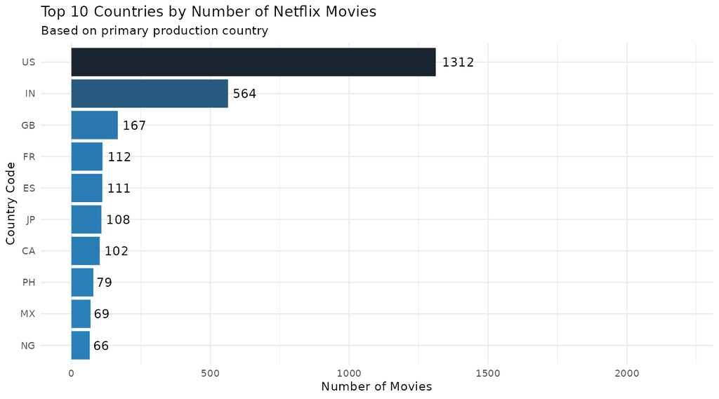

US and India dominate Netflix movie production by a wide margin.

**Key observations:**

- **US (1,312) dominates massively** — more than double the second place India (564). This reflects Netflix’s American origins and its primary English-language market
- **India (IN) is a significant second** — Bollywood’s enormous output makes India the second largest content contributor. Netflix has invested heavily in Indian original content
- **GB, FR, ES, JP, CA cluster tightly** between 100-167 movies — these represent Netflix’s core international expansion markets
- **Philippines (PH), Mexico (MX) and Nigeria (NG)** appearing in the top 10 signals Netflix’s deliberate push into emerging markets and local language content

**Implication for investors:** Netflix’s content is heavily US-centric. A competing service could differentiate by investing more deeply in underrepresented but high-growth markets like Southeast Asia and Sub-Saharan Africa.

## 3.2 Quality by Country

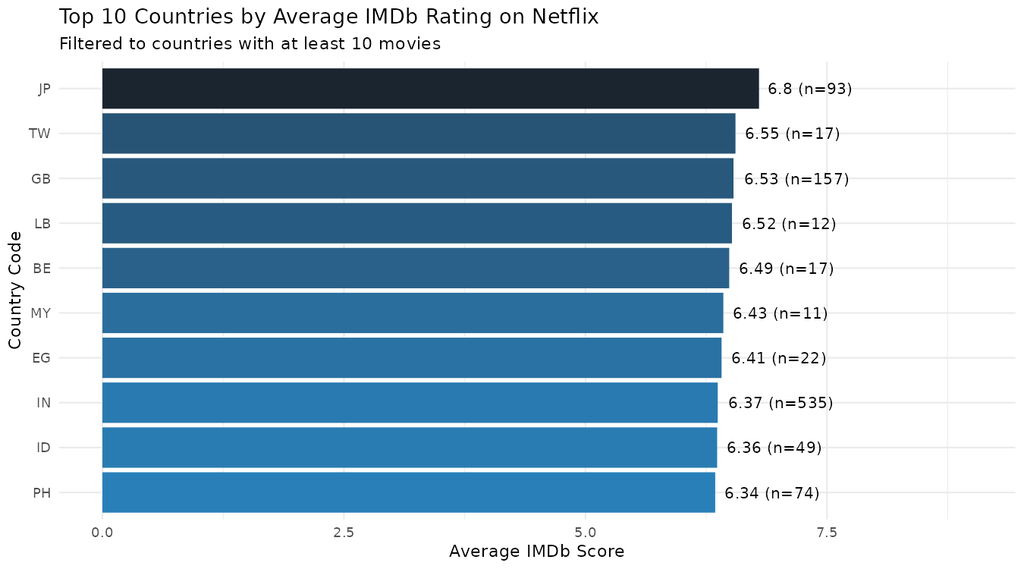

Japan leads in average IMDb rating. The US does not appear in the top 10.

**Key observations:**

- **Japan (JP) leads with 6.80** — Japanese cinema has a strong global reputation for artistic quality, and this shows across 93 movies
- **The US does not appear in the top 10** despite producing the most content — volume dilutes average quality. More content means more average and below-average titles alongside the standouts
- **Taiwan (TW) and Great Britain (GB)** take second and third — both known for selective, high-quality film traditions
- **Lebanon, Belgium and Malaysia** appearing shows that smaller production countries are more selective — they produce fewer but higher-quality films on average
- **India maintains 6.37 across 535 movies** — impressive quality consistency at high volume

**Key insight:** There is a clear inverse relationship between content volume and average rating. Countries producing fewer movies tend to be more selective. A competing service prioritising curation over volume could achieve higher average quality scores.

# 4 Movie Length Analysis

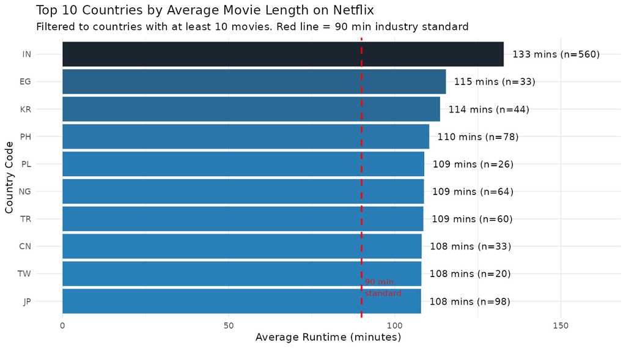

Non-Western countries consistently produce longer movies than the 90-minute standard.

**Implication for investors:** Non-Western audiences are accustomed to longer viewing sessions. A competing streaming service targeting international markets should invest in better progress tracking, chapter markers and pause-and-resume features optimised for longer content.

# 5 Genre Analysis

## 5.1 Most Popular Genres

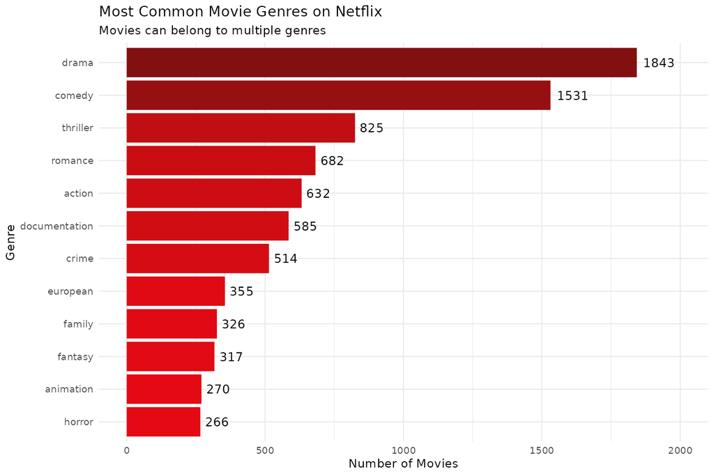

Drama and comedy dominate Netflix’s movie library by a significant margin.

**Key observations:**

- **Drama (1,843) and Comedy (1,531) dominate** — together accounting for the majority of Netflix movies. Both genres transcend language and cultural barriers, making them ideal for a global streaming platform
- **Thriller (825) is a strong third** — consistent with Netflix’s reputation for suspense content through successful originals
- **Documentation (585) is surprisingly prominent** — Netflix has made documentary content a key differentiator through high-profile releases
- **European (355) appearing as a genre tag** is notable — Netflix explicitly categorises certain content by regional style, acknowledging distinct European cinema traditions
- **Horror (266) is relatively low** despite its popularity — suggesting Netflix has not heavily invested in this genre, representing a potential gap for competitors

## 5.2 Textual Analysis of Descriptions

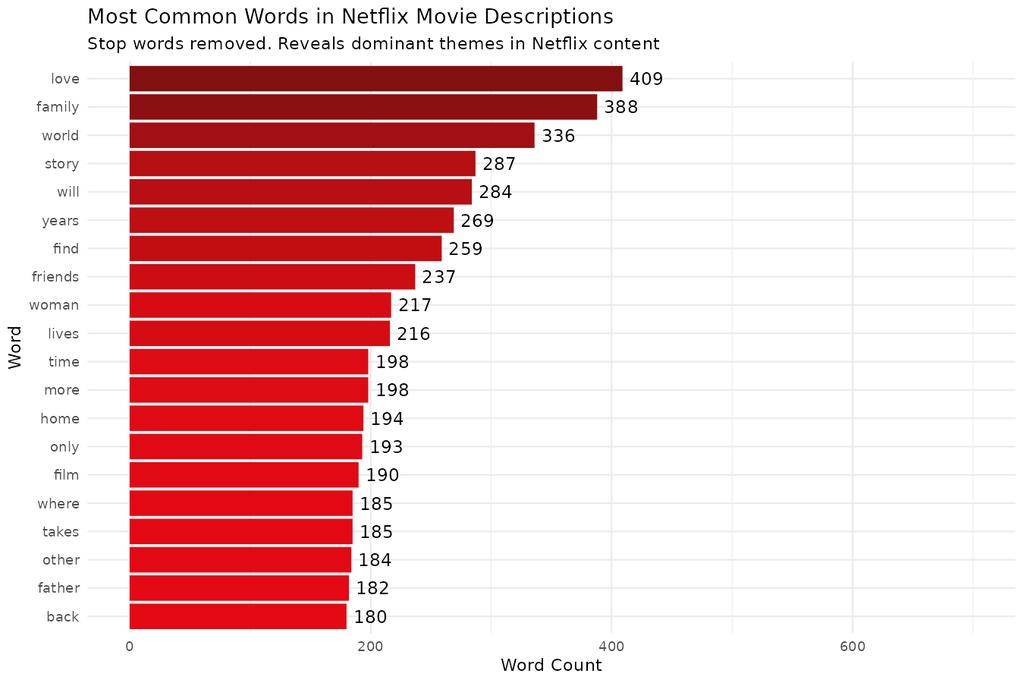

Love and family dominate Netflix movie descriptions, revealing the platform’s emotional storytelling focus.

**Key observations:**

- **Love (409) and Family (388)** are the top two words by a clear margin — emotional and relationship-driven storytelling is Netflix’s dominant content theme
- **World (336) and Story (287)** suggest epic and narrative-driven content alongside the relationship focus
- **Friends, Woman, Father** appearing prominently reveals that Netflix content centres heavily on personal relationships and family dynamics
- **The absence of action-oriented words** like fight, war, battle confirms that despite action being a notable genre, Netflix descriptions emphasise emotional themes over physical conflict
- This word profile aligns perfectly with the drama and comedy genre dominance — both genres rely on emotional and relational storytelling

# 6 Platform Comparison: Netflix vs HBO

## 6.1 Genre Strategy

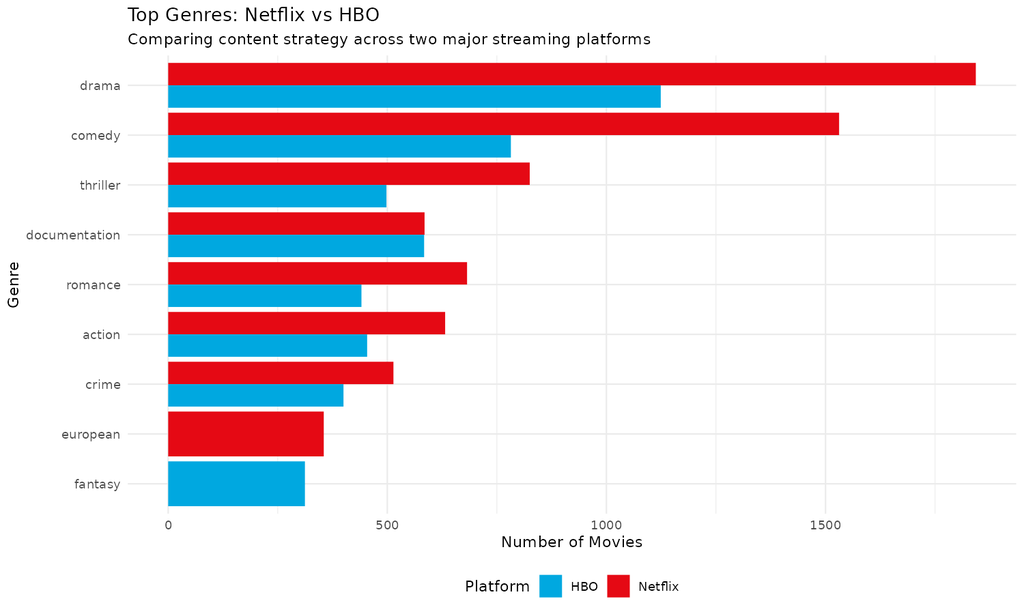

## 6.2 Ratings Comparison

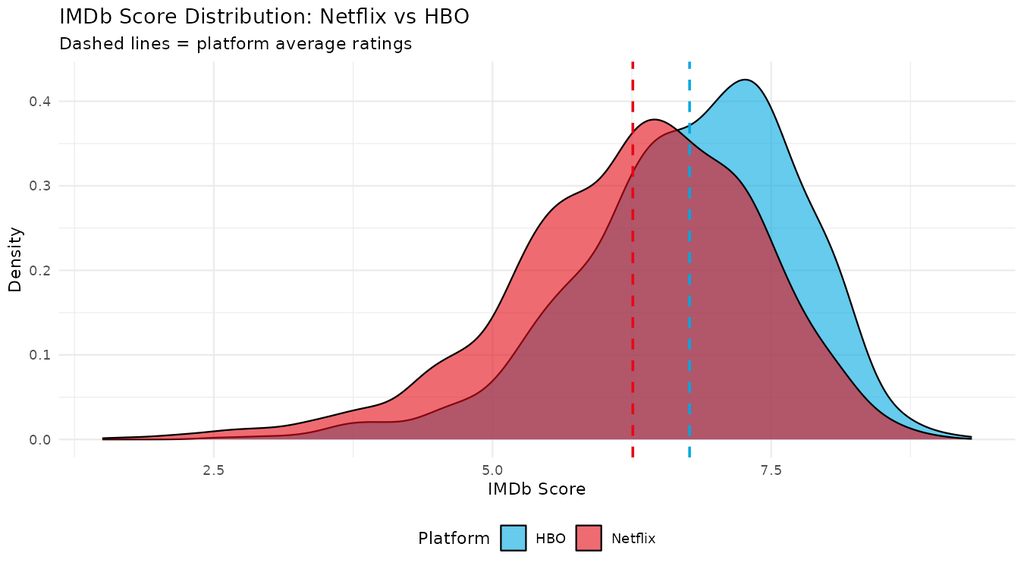

HBO maintains a higher average IMDb score than Netflix. HBO’s distribution is shifted right.

# 7 Conclusions and Recommendations

## 7.1 Key Conclusions

1. **Volume does not equal quality.** The US produces the most Netflix content but does not appear in the top 10 for ratings. Japan produces far less but leads on quality. A content strategy prioritising curation over volume is more likely to achieve sustained audience satisfaction.
2. **Non-Western content is longer and often higher quality.** Countries like India, South Korea, Egypt and Japan produce longer films that score well with audiences. These markets are underserved by Western streaming conventions and represent growth opportunities.
3. **Netflix’s emotional storytelling formula is dominant but predictable.** Love, family and friendship dominate across genres and descriptions. A competitor could differentiate through genre diversity — particularly horror, sci-fi and fantasy which are underrepresented on Netflix.
4. **HBO demonstrates that quality curation is a viable strategy.** A 0.51 IMDb point advantage over Netflix is meaningful at scale. Audiences notice quality differences and HBO’s model proves that fewer but better titles can build a strong brand.
5. **A market gap exists** for a platform combining HBO’s quality standards with Netflix’s genre breadth — particularly targeting international audiences with content from high-quality but underrepresented countries like Japan, South Korea and Taiwan.

## 7.2 Recommendations for the Investor Presentation

- **Do not compete on volume** — Netflix’s 3,721 movies cannot be matched at launch. Instead position as the quality alternative
- **Invest in Japan, South Korea and Taiwan originals** — these countries produce high quality content at reasonable cost with proven international appeal
- **Prioritise horror, sci-fi and fantasy** — these genres are underserved on Netflix and have dedicated passionate audiences
- **Target longer-form international content** — non-Western audiences want longer movies and Netflix’s UI is optimised for shorter content. Build a better experience for 2+ hour films
- **Use IMDb and TMDB scores as acquisition filters** — only license content scoring above 7.0 IMDb to build a quality reputation from launch
- **Invest in documentary content** — Netflix has proven this is a high-engagement genre that drives subscriptions and critical acclaim

*Data sources: IMDb movie database, Netflix titles catalogue (up to 2022), HBO titles catalogue. Analysis based on 5,765 Netflix titles and 3,294 HBO titles with valid IMDb scores.*